# Paths Instructions

Math 252 – Spring 2020

2/11/2020

# Instructions

A. Work in groups of 3 or 4. Put all of your group members’ names in the space below:

B. Have one person in your group be the official recorder for the group. The recorder’s job is to record your work on some of the problems on this sheet. Feel free to rotate the recorder duties.

C. At the end of the hour, make sure all of these group sheets get turned in.

D. The homework due today will be collected on Friday instead of today.

1. What is a path of length 0?
2. Can a path of length 1 be a circuit? If so, draw an example. If not, explain why not.
3. Why are paths defined in terms of edges rather than vertices? In what situations does it matter? When does it not matter?

## Paths and Isomorphism

If $f : G \to H$ is an isomorphism, then $f$ maps paths in $G$ to paths in $H$. (Why?) This can be useful for finding an isomorphism between $G$ and $H$ or for showing that there is no isomorphism.

4. Consider the pair of graphs below. Are the graphs isomorphic? Explain.

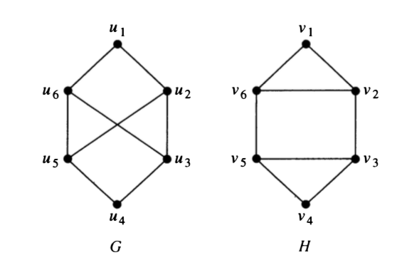

## Euler and Hamilton Paths

- An **Euler path** is a path that visits every edge of a graph exactly once.
- A **Hamilton path** is a path that visits every vertex exactly once.

Euler paths are named after Leonid Euler who posed a famous problem about the bridges in Königsberg. Hamilton paths are named after the Irish mathematician William Rowan Hamilton, not after the American politician Alexander Hamilton.

## Relationships in Graphs

A **planar graph** is a graph that *can be* drawn in the plane without any edges crossing.

8. Show that $K_4$ is a planar graph by drawing it without any edge crossings.
9. Show that $Q_3$ is a planar graphs by drawing it without any edge crossings.
10. Here are some graphs that are missing their vertices. Add dots showing vertices so that each graph is a planar graph.

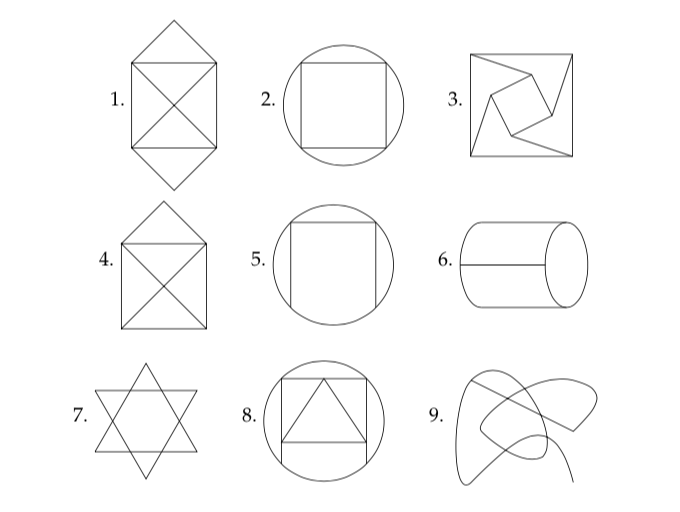

11. Fill in the table below for the graphs above. Do you notice any patterns? Can you make any conjectures? Can you prove any of the conjectures? (Note: an even vertex is a vertex with even degree. An odd vertex is a vertex with odd degree.)

| Graph | number of even verticies | number of odd vertices | total degree | number of vertices | number of edges | number of regions | Euler path? | Euler circuit? |
| --- | --- | --- | --- | --- | --- | --- | --- | --- |
| 1 |  |  |  |  |  |  |  |  |
| 2 |  |  |  |  |  |  |  |  |
| 3 |  |  |  |  |  |  |  |  |
| 4 |  |  |  |  |  |  |  |  |
| 5 |  |  |  |  |  |  |  |  |
| 6 |  |  |  |  |  |  |  |  |
| 7 |  |  |  |  |  |  |  |  |
| 8 |  |  |  |  |  |  |  |  |
| 9 |  |  |  |  |  |  |  |  |